# The Radical Right and the Politicization of Climate Policy

Sara Hobolt and Zach Dickson

London School of Economics

### The Radical Right and Climate Change

[figure not shown]

[figure not shown]

[figure not shown]

[figure not shown]

# Party Competition and Wedge Issue Politics

- **Party competition** is central to understanding policy outcomes
- Parties compete on **issue ownership** (Bélanger and Meguid 2008) and **entrepreneurship** (de Vries and Hobolt 2020)
  - Issue owners are widely recognized as **experts** on the issue
  - Entrepreneurial parties seek to **change the status quo** by politicizing new issues

# Climate Change as a Wedge Issue

*What would a wedge issue strategy look like?*

1. **Issue attention**
   - RR parties increase salience of climate issues
2. **Adversarial positioning**
   - RR parties take an oppositional stance on climate policy
3. **Mobilizing potential**
   - A significant share of voters hold sceptical views of climate change policies

# Expectations

- Increase in **salience** of climate issues for radical right parties
- RR parties will take an **adversarial position** on climate policy
- A significant share of voters who *do not already* support the RR hold **sceptical views**

## Research Design & Methods

- ~500k Party Press Releases from 76 parties (2010-2022)
  - Includes over 50k press releases from radical right parties
- European Social Survey data
- UK and German Election Study Panel Data
- **Text analysis** to measure salience and adversarial positioning
  - Train and validate large language models for:
  - [Text classification](https://huggingface.co/z-dickson/CAP_multilingual)
  - [Generative summarization](https://huggingface.co/z-dickson/bart-large-cnn-climate-change-summarization)

[figure not shown]

## Party Press Releases

[figure not shown]

# Results: Salience

> Radical right parties are increasingly focusing on climate issues

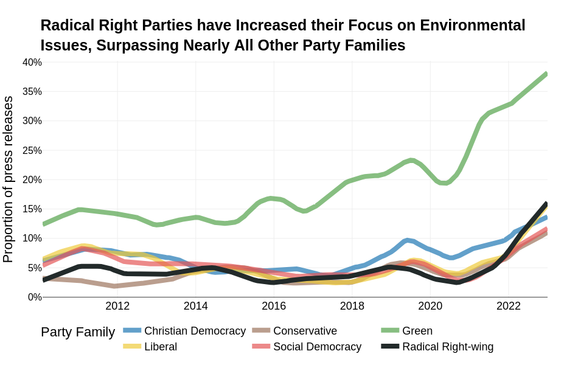

# Results: Adversarial Position

> Radical right parties are uniquely oppositional on climate issues

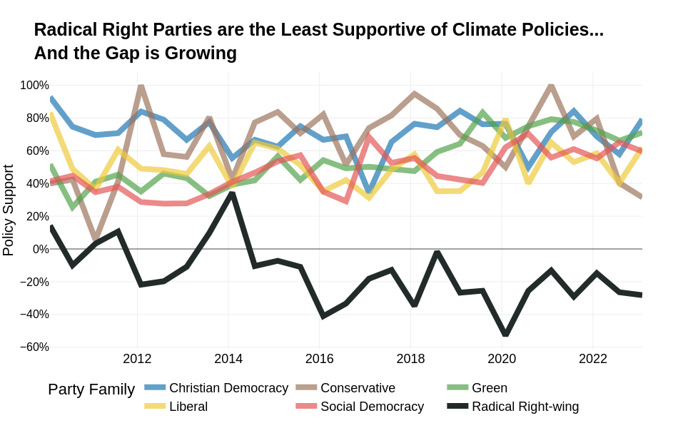

# Results: Mobilizing Potential

> A significant share of voters across parties hold sceptical views

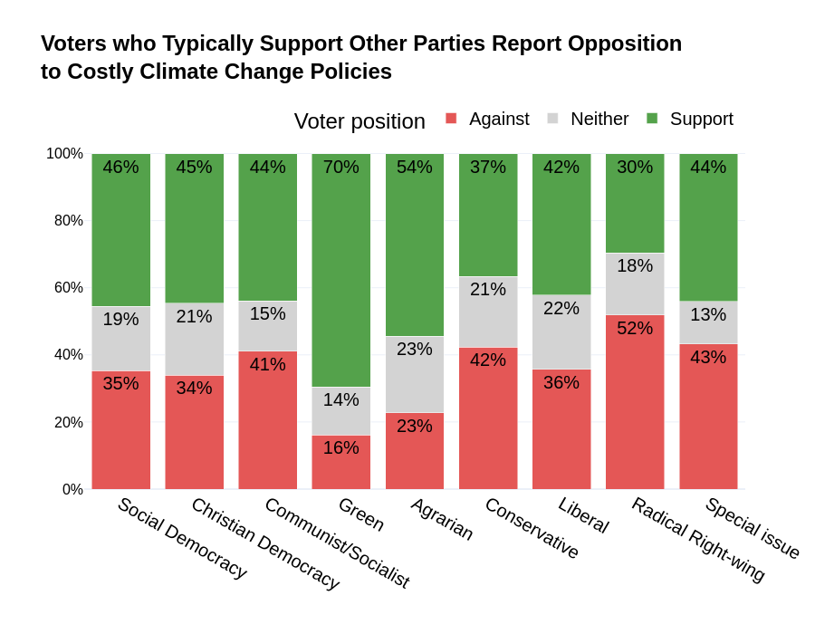

# Vote Switching

> Radical right parties are mobilizing voters

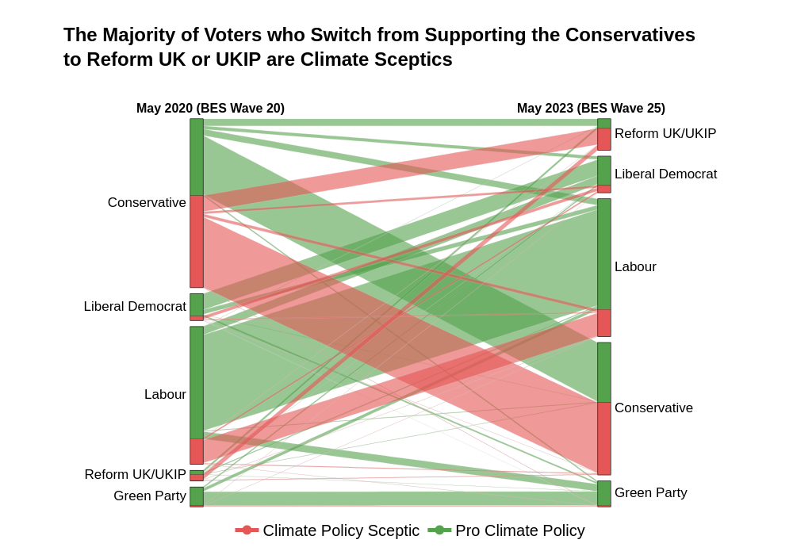

# Discussion

- Climate change is a **wedge issue** that divides mainstream coalitions
- Radical right parties are increasingly **politicizing** climate change
  - Increasing salience
  - Taking adversarial positions
  - Mobilizing voters

# How Can Mainstream Parties Respond?

- **Accommodation**
  - Germany, UK, Australia: Accommodating radical right positions on climate change
  - **Risk**: Undermining climate policy and mainstream party credibility
    - **Alienation** of pro-climate voters
- **Address the Distributional Consequences of Climate Policy**
  - Socially fair climate action
  - Failure to address the costs for lower- and middle-income groups risks backlash
- **Communicate Climate Policy in Terms of Security and Sovereignty**
  - Reframe climate action not as sacrifice, but as a protection of national economic and social interests to counter radical right narratives

## Thank You!

- **Article:** Dickson & Hobolt (2024). [Going Against the Grain: Climate Change as a Wedge Issue for the Radical Right](https://journals.sagepub.com/doi/10.1177/00104140241271297). *Comparative Political Studies*

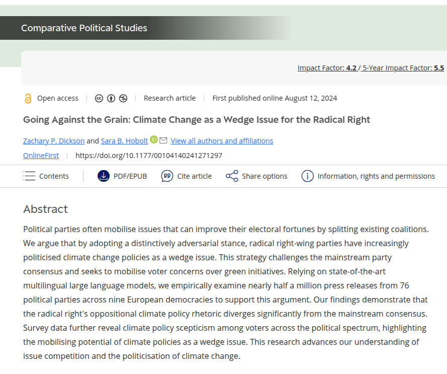

# References

Bélanger, Éric, and Bonnie M Meguid. 2008. “Issue Salience, Issue Ownership, and Issue-Based Vote Choice.” *Electoral Studies* 27 (3): 477–91.

de Vries and Hobolt. 2020. *Political Entrepreneurs: The Rise of Challenger Parties in Europe*. Princeton University Press.